Bacterial Genome Sequencing Results

# Summary

## 8CQS4J_1

#### 2025-05-23

**Overview of assembly and annotation**

- This is a [circos plot](https://genome.cshlp.org/content/19/9/1639) generated by [Bakta](https://www.microbiologyresearch.org/content/journal/mgen/10.1099/mgen.0.000685) (v1.11).
- It is a circular representation of all of the contigs, and contains information such as GC skew and feature location. See [Bakta’s explanation](https://github.com/oschwengers/bakta#description-1) for more detail.

[figure not shown]

#### **Statistics**

| Total bp sequenced | 770,852,207 bp |
| --- | --- |
| Total number of reads | 272,886 reads |
| Longest read | 85,555 bp |
| Raw coverage | 199x |
| Assembled coverage | 78x |
| Genome size (Mb) | 3.9 Mb |
| Number of contigs | 6 contigs |
| Number of genes annotated | 3,563 genes |

**All data is contained within the accompanying folders.**

# Results

## Contig analysis

**Assembly graph**

- This is an [assembly graph](https://github.com/rrwick/Unicycler#assembly-graphs) generated by [Bandage](https://academic.oup.com/bioinformatics/article/31/20/3350/196114) (v0.8.1).
- It shows the contigs and their connections in the assembly.
- Generally, the best graph you can have for a bacterial genome is a single circle (and possibly some other circles if you have plasmids).
- If a contig is **black**, it has a relative depth of x1.
- If a contig is **red** it has a higher relative depth, suggesting it has higher abundance in the sample.
- **Note**: This is a graph of the pre-polished assembly. During [Medaka](https://github.com/nanoporetech/medaka) polishing, some contigs may be deleted if they are not well-supported, meaning that this plot may show extra contigs.

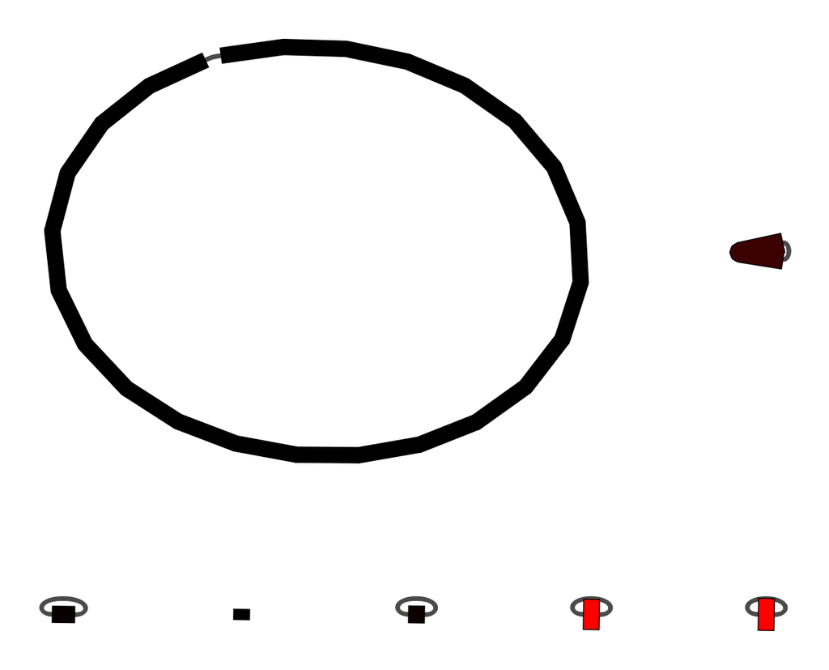

## Species analysis

### Mash

**Taxonomic classification**

- This shows the highest scoring [Mash](https://genomebiology.biomedcentral.com/articles/10.1186/s13059-019-1841-x) (v2.3) hit against a prepared [RefSeq](https://academic.oup.com/nar/article/44/D1/D733/2502674) database for each contig in your assembly (database download in [section 3.1.4](https://readthedocs.org/projects/mash/downloads/pdf/latest/)).
- The percent identity is estimated from the number of [kmers](https://en.wikipedia.org/wiki/K-mer) that matched the reference.

| contig | length (bp) | species | est. %ID |
| --- | --- | --- | --- |
| contig_2 | 215,250 | NZ_CP050139.1 Komagataeibacter rhaeticus strain ENS 9a1a chromosome | 86.7 |
| contig_3 | 3,571,347 | NZ_CP050139.1 Komagataeibacter rhaeticus strain ENS 9a1a chromosome | 99.6 |
| contig_4 | 54,650 | NZ_CP050139.1 Komagataeibacter rhaeticus strain ENS 9a1a chromosome | 79.60000000000001 |
| contig_5 | 5,256 |  |  |
| contig_6 | 8,374 | NZ_CP050139.1 Komagataeibacter rhaeticus strain ENS 9a1a chromosome | 68.89999999999999 |
| contig_7 | 15,436 | NZ_CP050139.1 Komagataeibacter rhaeticus strain ENS 9a1a chromosome | 76.7 |

**Mash may incorrectly identify bacterial contigs as plasmids or phage**

See the FAQ for more information.

### Sourmash

**An alternative method**

- [Sourmash](https://joss.theoj.org/papers/10.21105/joss.00027) (v4.6.1) has more or less the same functionality as Mash the way we use it, however we query Sourmash against a [prepared GenBank database](https://sourmash.readthedocs.io/en/latest/command-line.html#sourmash-lca-subcommands-for-in-memory-taxonomy-integration).
- The algorithm and database are calibrated differently than what is used in the Mash analysis step, so it is often less sensitive in finding exact hits.

| contig | superkingdom | phylum | class | order | family | genus | species | strain |
| --- | --- | --- | --- | --- | --- | --- | --- | --- |
| contig_2 | Bacteria | Proteobacteria | Alphaproteobacteria | Rhodospirillales | Acetobacteraceae |  |  |  |
| contig_3 | Bacteria | Proteobacteria | Alphaproteobacteria | Rhodospirillales | Acetobacteraceae |  |  |  |
| contig_4 |  |  |  |  |  |  |  |  |
| contig_5 |  |  |  |  |  |  |  |  |
| contig_6 |  |  |  |  |  |  |  |  |
| contig_7 |  |  |  |  |  |  |  |  |

## Overview of sequencing reads

**Plot of all reads**

- Each **dot** on the graph represents a single read, plotted by its length and its mean [Phred quality score](https://en.wikipedia.org/wiki/Phred_quality_score).
- **Red** dots are reads *not* used the assembly.
- **Blue** dots are reads used in the assembly.
- The histograms along the top and right show the distribution of read lengths and Phred scores, respectively.
- `median phred` line shows the median Phred score of all of the reads used in the assembly.

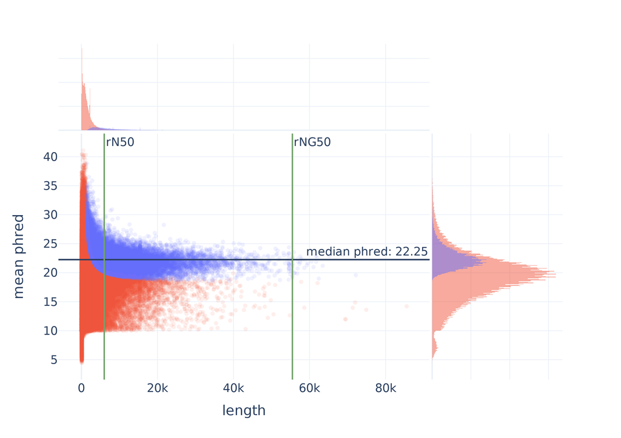

| rN50 | rNG50 |
| --- | --- |
| 6,010 bp | 55,497 bp |

**What do rN50 and rNG50 mean?**

- These are assembly statistics that help assess read/assembly quality.
- **rN50** is the “reads N50”, which is defined as the shortest read that covers 50% of the total number of bases in the reads used for assembly. [This](https://www.molecularecologist.com/2017/03/29/whats-n50/) is a good reference for better understanding N50, though note that we are reporting rN50 which uses reads instead of contigs.
- **rNG50** is the “*genome* reads N50”. We made this statistic up! However, it’s analogous to a NG50, which takes into account the known or estimated genome size. After assembly, we use the genomic length information to calculate the length where half of the genome is covered by reads of this length or longer.

## Assembly completeness

### CheckM

✅ **Your genome assembly passed the reference gene check.**

**Is the assembly complete?**

- [CheckM](https://genome.cshlp.org/content/25/7/1043) (v1.2.2) assesses the quality of genome assemblies. It uses a set of reference gene profiles to assess the completeness, contamination, and strain heterogeneity of a given assembly.
- This displays the contigs which the specific CheckM reference genes were found. The reference genes are almost always chromosomal, so if a contig plot shows it contains references genes, it is likely chromosomal.
- Why do my completeness and contamination numbers look slightly off?

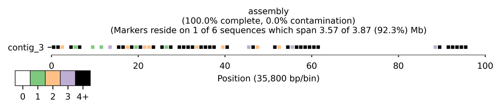

| Marker lineage | Completeness | Contamination |
| --- | --- | --- |
| o__Rhodospirillales (UID3754) | 100 | 0 |

# FAQ

### Where are my FASTA files? Where are my annotated DNA sequences?

- If your sequencing run succeeded, these files can be found within the accompanying `annotation` folder, which was generated by [Bakta](https://www.microbiologyresearch.org/content/journal/mgen/10.1099/mgen.0.000685). Bioinformatics file extensions can be confusing and somewhat inconsistent. Here is a quick guide to some of file extensions you will find in your `annotation` folder:
  - FASTA files:
    - `.fna` (contig nucleotide sequences)
    - `.faa` (protein amino acid sequences)
    - `.ffn` (gene nucleotide sequences)
  - GenBank files:
    - `.gbff` (annotated contig sequences)
- You should be able to open any of these files in your favorite sequence editor (e.g.: Geneious, SnapGene, Benchling, MacVector, CLC, UGENE, etc.).

### What is a “contig”?

- This is a **contig**uous segment of DNA assembled from the sequencing reads. It may or may not represent an entire genome or entire plasmid. Generally, if your assembly graph is solely comprised of circles, each contig represents a single genome or plasmid.

### My assembly graph is *not* a circle – why does it look like a complete mess?

- If your plot is not a circle and has a more complicated path, this could be due to several reasons, including:
  - Your DNA sample was degraded and there were not enough longer reads to bridge repetitive regions (investigate your reads to assess). [Check out our guide](https://www.plasmidsaurus.com/static/img/bacteria.pdf) on preparing bacterial DNA samples for sequencing. This is the most likely cause.
  - Your genome is incredibly repetitive due to IS elements or other genomic features.
  - Your genome was very large and there were not enough reads to satisfactorily cover the genome.
  - You had a contaminant organism which reduced the overall genome coverage.

### How do you determine which reads are used in the assembly?

- We remove the bottom 5% of all reads that don’t reach a certain quality threshold, defined by both the Phred quality and length.
- We further remove excess reads if the total coverage of the reads used in the assembly is greater than 100x.

### Why does my Mash analysis say that my contig is a plasmid/phage when that is clearly incorrect?

- Since Mash is using the RefSeq database including bacterial genomes, plasmids, and phages, it is possible to have a chromosomal contig labeled as a plasmid or phage if it scores higher than the genome it is contained within.
- This is why we use Sourmash with a different reference database and search strategy – if Mash gives strange results this can be a good second opinion.
- CheckM will also search bacterial and archaeal profiles giving an independent third opinion.

### My genome looks good, but why is CheckM reporting only 98% complete and 3% contamination?

- While CheckM is a fantastic tool, it rarely scores genomes as 100% complete with 0% contamination, even when run on “perfect” genomes. Biology is weird, and the supposedly single-copy genes that CheckM looks for may be legitimately missing or duplicated leading to slightly erroneous results.
- Some of the discrepancies may be explained by small errors in the assembly process (see below), but it is more likely that the above is causing the discrepancy.

### My contigs are circles and everything looks good – is my genome assembly perfect?

- It’s possible! However, it’s more likely that your genome assembly still contains SNPs (single nucleotide polymorphisms), especially in regions where ONT reads have higher error rates, such as long homopolymers. It’s also possible, though less likely than SNPs, that your genome assembly contains medium-sized structural errors ([e.g.: deleting 50 bp from the end of a contig](https://github.com/rrwick/Trycycler/wiki)). For the very best possible assembly, we recommend trying your hand at using [Trycycler](https://genomebiology.biomedcentral.com/articles/10.1186/s13059-021-02483-z) to assemble your genomes and polishing with Illumina reads. Trycycler is a manual pipeline and can be quite labor intensive. While very high quality, the genome assemblies we return should be treated as draft assemblies.

### How is the assembly generated?

1. Remove the bottom 5% worst fastq reads via Filtlong v0.2.1 (default parameters)
2. Downsample the reads to 250 Mb via Filtlong to create a rough sketch of the assembly with [Miniasm](https://academic.oup.com/bioinformatics/article/32/14/2103/1742895) v0.3
3. Using information acquired from the Miniasm assembly, re-downsample the reads to ~100x coverage (do nothing if there isn’t at least 100x coverage) with heavy weight applied to removing low quality reads (`filtlong --mean_q_weight 10`)
4. Run a [Flye](https://www.nature.com/articles/s41587-019-0072-8) v2.9.1 assembly with parameters selected for high quality ONT reads
5. Polish Flye assembly via [Medaka](https://github.com/nanoporetech/medaka) v1.8.0 using the reads generated in step 3
6. Run several analyses:
   - annotation
     - [Bakta](https://www.microbiologyresearch.org/content/journal/mgen/10.1099/mgen.0.000685) v1.11
   - contig analysis
     - [Bandage](https://academic.oup.com/bioinformatics/article/31/20/3350/196114) v0.8.1
   - genome completeness and contamination
     - [CheckM](https://genome.cshlp.org/content/25/7/1043) v1.2.2
   - species / plasmid identification
     - [Mash](https://genomebiology.biomedcentral.com/articles/10.1186/s13059-019-1841-x) v2.3 against RefSeq genomes+plasmids
     - [Sourmash](https://joss.theoj.org/papers/10.21105/joss.00027) v4.6.1 against GenBank
     - [CheckM](https://genome.cshlp.org/content/25/7/1043) v1.2.2